# Health and economic impact of weather events in the United States

## Synopsis

In this report I aim to describe wich weather events has the greatest impact in the economy of the US and in the population health.  
To investigate that I obtained a database from the Reproducible Research Course web site. This database tracks characteristics of major storms and weather events in the United States for the period 1950-2011.  
From this data, I found that the event that has caused more deaths and injuries to the population are the Tornados. In terms of economic impact, the event with worst consequences has been the Floods. In this last analysis if I separate the information between Properties damage and Crops damage I found that the Floods has been the event with more impact in properties but Drought has been the event with the worst impact in crops. I found these last conclusion as the most interesting of my analysis.

## Data Processing

[From the Reproducible Research course web site](https://www.coursera.org/learn/reproducible-research/peer/OMZ37/course-project-2) I obtained the storm database of the NOAA. This database tracks characteristics of major storms and weather events in the United States for the period 1950-2011.

```r
StormData <- read.csv("repdata_data_StormData.csv")
```

### The first question I want to answer is which type of event is most harmful with respect to population health.

In order to do this first I need only the columns “EVTYPE”, “FATALITIES”, and “INJURIES”

```r
library(dplyr)
```

```r
harmbyevent <- StormData %>%
        select(EVTYPE, FATALITIES, INJURIES) %>%
        group_by(EVTYPE)
```

I inserted a new column with the sum of fatalities and injuries.

```r
harmbyevent$TOTAL <- harmbyevent$FATALITIES + harmbyevent$INJURIES
```

I saw the differents types of events, in the column “EVTYPE”:

```r
unique(harmbyevent$EVTYPE)
```

```
##   [1] TORNADO                        TSTM WIND
##   [3] HAIL                           FREEZING RAIN
##   [5] SNOW                           ICE STORM/FLASH FLOOD
##   [7] SNOW/ICE                       WINTER STORM
##   [9] HURRICANE OPAL/HIGH WINDS      THUNDERSTORM WINDS
##  [11] RECORD COLD                    HURRICANE ERIN
##  [13] HURRICANE OPAL                 HEAVY RAIN
##  [15] LIGHTNING                      THUNDERSTORM WIND
##  [17] DENSE FOG                      RIP CURRENT
##  [19] THUNDERSTORM WINS              FLASH FLOOD
##  [21] FLASH FLOODING                 HIGH WINDS
##  [23] FUNNEL CLOUD                   TORNADO F0
##  [25] THUNDERSTORM WINDS LIGHTNING   THUNDERSTORM WINDS/HAIL
##  [27] HEAT                           WIND
##  [29] LIGHTING                       HEAVY RAINS
```

[output cut: 479 more lines]

I could see that the information of the type of event is confusing, with events that seem to be the same but are written slightly differently.

I started to clarify this column:

First I changed all the events to a “uppercase” text and then I removed the leading and trailing whitespaces. Doing that the types of event decreased from 985 to 890.

```r
harmbyevent$EVTYPE <- trimws(toupper(harmbyevent$EVTYPE))
```

I summarized the data by total of harm per event.

```r
totalharmbyevent <- harmbyevent %>%
                summarize(TOTAL=sum(TOTAL)) %>%
                arrange(desc(TOTAL))%>%
                print
```

I selected only the 10 events most harmful.

```r
totalharmbyevent <- totalharmbyevent[1:10,]
totalharmbyevent
```

```
## # A tibble: 10 x 2
##    EVTYPE            TOTAL
##    <fct>             <dbl>
##  1 TORNADO           96979
##  2 EXCESSIVE HEAT     8428
##  3 TSTM WIND          7461
##  4 FLOOD              7259
##  5 LIGHTNING          6046
##  6 HEAT               3037
##  7 FLASH FLOOD        2755
##  8 ICE STORM          2064
##  9 THUNDERSTORM WIND  1621
## 10 WINTER STORM       1527
```

Some events appears to be the same, for example “EXCESSIVE HEAT/HEAT” and “TSTM WIND/THUNDERSTORM WIND”. I ordered the column EVTYPE and I saw that some events were repeated.

```r
typesofevent <- sort(as.character(unique(harmbyevent$EVTYPE)))
typesofevent
```

```
##   [1] "?"                              "ABNORMAL WARMTH"
##   [3] "ABNORMALLY DRY"                 "ABNORMALLY WET"
##   [5] "ACCUMULATED SNOWFALL"           "AGRICULTURAL FREEZE"
##   [7] "APACHE COUNTY"                  "ASTRONOMICAL HIGH TIDE"
##   [9] "ASTRONOMICAL LOW TIDE"          "AVALANCE"
##  [11] "AVALANCHE"                      "BEACH EROSIN"
##  [13] "BEACH EROSION"                  "BEACH EROSION/COASTAL FLOOD"
##  [15] "BEACH FLOOD"                    "BELOW NORMAL PRECIPITATION"
##  [17] "BITTER WIND CHILL"              "BITTER WIND CHILL TEMPERATURES"
##  [19] "BLACK ICE"                      "BLIZZARD"
##  [21] "BLIZZARD AND EXTREME WIND CHIL" "BLIZZARD AND HEAVY SNOW"
##  [23] "BLIZZARD SUMMARY"               "BLIZZARD WEATHER"
##  [25] "BLIZZARD/FREEZING RAIN"         "BLIZZARD/HEAVY SNOW"
##  [27] "BLIZZARD/HIGH WIND"             "BLIZZARD/WINTER STORM"
##  [29] "BLOW-OUT TIDE"                  "BLOW-OUT TIDES"
```

[output cut: 430 more lines]

I adjusted some event’s name that I could find that were repeated. Doing that the types of events decreased from 890 to 682.

```r
library(mgsub)
```

```r
harmbyevent$EVTYPE <- mgsub(string=harmbyevent$EVTYPE,
                            pattern=c(".*TORNADO|TORNADOES|TORNDAO.*",".*HEAT.*",
                                      ".*TSTM WIND|TSTM WND|TSTMW|THUNDERSTORM WIND.*",
                                      ".*FLOOD.*", ".*LIGHTNING|LIGNTNING.*",
                                      ".*ICE STORM.*", ".*WINTER STORM.*", ".*HURRICANE.*",
                                      ".*STORM SURGE.*", ".*TROPICAL STORM.*"),
                            replacement = c("TORNADO", "HEAT", "TSTM WIND", "FLOOD",
                                            "LIGHTNING", "ICE STORM", "WINTER STORM",
                                            "HURRICANE", "STORM SURGE", "TROPICAL STORM"))
str(unique(harmbyevent$EVTYPE))
```

```
##  chr [1:682] "TORNADO" "TSTM WIND" "HAIL" "FREEZING RAIN" "SNOW" "FLOOD" ...
```

I summarized the data again by total of harm per event, and then I selected only the most 5 harmful events.

```r
finalharmtable <- harmbyevent %>%
        group_by(EVTYPE) %>%
        summarize(TOTAL=sum(TOTAL))%>%
        arrange(desc(TOTAL))
finalharmtable <- finalharmtable[1:5,]
finalharmtable
```

```
## # A tibble: 5 x 2
##   EVTYPE    TOTAL
##   <chr>     <dbl>
## 1 TORNADO   97025
## 2 HEAT      12362
## 3 FLOOD     10129
## 4 TSTM WIND 10080
## 5 LIGHTNING  6046
```

In order to complete the analysis, I created two new tables to see if the same event is also the event with more fatalities and more injuries if we analysed it separately, and not only as a sum of fatalities and injuries.

```r
totalfatalities <- harmbyevent %>%
        group_by(EVTYPE) %>%
        summarize(FATALITIES = sum(FATALITIES)) %>%
        arrange(desc(FATALITIES))
```

```r
totalinjuries <- harmbyevent %>%
        group_by(EVTYPE) %>%
        summarize(INJURIES=sum(INJURIES)) %>%
        arrange(desc(INJURIES))
```

### The second question I want to answer is wich types of events have the greatest economic consequences?

In order to do this first I need only the columns “EVTYPE”, “PROPDMG”, “PROPDMGEXP”, “CROPDMG” and “CROPDMGEXP”

```r
economicimpact <- StormData %>%
        select(EVTYPE, PROPDMG, PROPDMGEXP, CROPDMG, CROPDMGEXP) %>%
        print
```

I did the same adjustments to the column EVTYPE that I did for question 1 in order to solve some duplicates and spelling mistakes.

```r
economicimpact$EVTYPE <- trimws(toupper(economicimpact$EVTYPE))
economicimpact$EVTYPE <- mgsub(string=economicimpact$EVTYPE,
                            pattern=c(".*TORNADO|TORNADOES|TORNDAO.*",".*HEAT.*",
                                      ".*TSTM WIND|TSTM WND|TSTMW|THUNDERSTORM WIND.*",
                                      ".*FLOOD.*", ".*LIGHTNING|LIGNTNING.*",
                                      ".*ICE STORM.*", ".*WINTER STORM.*", ".*HURRICANE.*",
                                      ".*STORM SURGE.*", ".*TROPICAL STORM.*"),
                            replacement = c("TORNADO", "HEAT", "TSTM WIND", "FLOOD",
                                            "LIGHTNING", "ICE STORM", "WINTER STORM",
                                            "HURRICANE", "STORM SURGE", "TROPICAL STORM"))
```

I analysed what is included in the columns PROPDMGEXP and CROPDMGEXP:

```r
unique(economicimpact$PROPDMGEXP)
```

```
##  [1] K M   B m + 0 5 6 ? 4 2 3 h 7 H - 1 8
## Levels:  - ? + 0 1 2 3 4 5 6 7 8 B h H K m M
```

```r
unique(economicimpact$CROPDMGEXP)
```

```
## [1]   M K m B ? 0 k 2
## Levels:  ? 0 2 B k K m M
```

These columns include the exponent for the number in the columns PROPDMG and CROPDMG. I substituted this code for the number that corresponds in each case:

```r
economicimpact$PROPDMGEXP <- mgsub(string=as.character(economicimpact$PROPDMGEXP),
                                   pattern = c(".*-|?|+|0.*","", "1", "2|h|H", "3|k|K",
                                               "4", "5", "6|M|m", "7", "8", "B"),
                                   replacement = c("1","1", "10", "100", "1000", "10000",
                                                   "100000", "1000000", "10000000",
                                                   "100000000", "1000000000"))
```

```r
economicimpact$CROPDMGEXP <- mgsub(string=as.character(economicimpact$CROPDMGEXP),
                                   pattern = c("?|0","", "2", "B", "k|K", "M|m"),
                                   replacement = c("1","1", "100", "1000000000", "1000",
                                                   "1000000"))
```

I created 3 new columns:  
- Total of property damage  
- Total of crop damages  
- Total damage (sum of property and crop)

```r
economicimpact$PROPERTYDAMAGE <- economicimpact$PROPDMG * as.numeric(economicimpact$PROPDMGEXP)
economicimpact$CROPDAMAGE <- economicimpact$CROPDMG * as.numeric(economicimpact$CROPDMGEXP)
economicimpact$TOTALDAMAGE <- economicimpact$PROPERTYDAMAGE + economicimpact$CROPDAMAGE
```

I summarized the data by total of economic impact, and then I selected the 5 events with more impact. I show the information in Billions of dollars to make it more readable.

```r
totalimpact <- economicimpact %>%
        group_by(EVTYPE) %>%
        summarize(TOTALDAMAGE=sum(TOTALDAMAGE, na.rm = TRUE))%>%
        arrange(desc(TOTALDAMAGE))%>%
        mutate(TOTALDAMAGE = TOTALDAMAGE/1000000000)%>%
        rename(DAMAGE_IN_BUSD=TOTALDAMAGE)
totalimpact <- totalimpact [1:5,]
totalimpact
```

```
## # A tibble: 5 x 2
##   EVTYPE    DAMAGE_IN_BUSD
##   <chr>              <dbl>
## 1 FLOOD             158.
## 2 HURRICANE          44.3
## 3 TORNADO            16.6
## 4 HAIL               10.0
## 5 ICE STORM           5.93
```

In order to complete the analysis, I created two new tables to see if the same event is also the event with more property damage and more crop damage if we analysed it separately, and not only as a sum of property and crop.

```r
totalpropdamage <- economicimpact %>%
        group_by(EVTYPE) %>%
        summarize(PROPERTYDAMAGE_MUSD = sum(PROPERTYDAMAGE, na.rm = TRUE)/1000000) %>%
        arrange(desc(PROPERTYDAMAGE_MUSD))
```

```r
totalcropdamage <- economicimpact %>%
        group_by(EVTYPE) %>%
        summarize(CROPDAMAGE_MUSD = sum(CROPDAMAGE, na.rm = TRUE)/1000000) %>%
        arrange(desc(CROPDAMAGE_MUSD))
```

## Results

### Which type of event is most harmful with respect to population health?

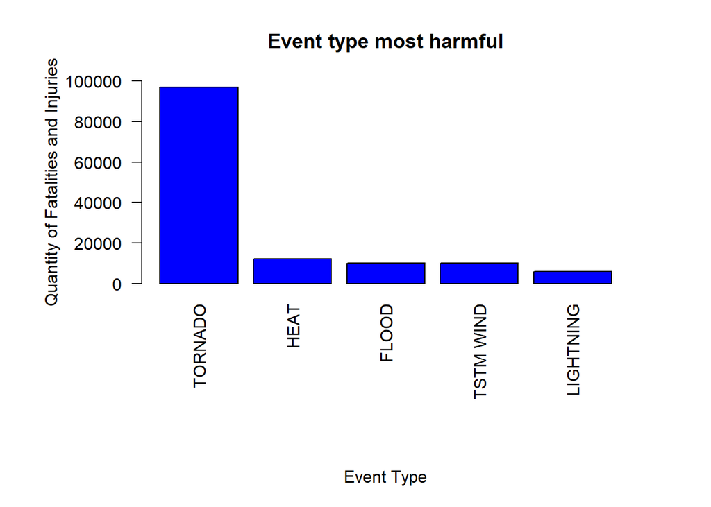

```r
par(mar=c(11, 7, 4, 4))
with(finalharmtable, barplot(height = TOTAL,
                               col= "blue",
                               main = "Event type most harmful",
                               yaxt="n",
                               xlab="", ylab="",
                               ylim= c(0,100000),
                               names.arg = EVTYPE,
                               las = 2))
mtext(text="Event Type", side = 1, line = 9)
mtext(text="Quantity of Fatalities and Injuries", side = 2, line = 4)
axis(2, at=pretty(finalharmtable$TOTAL),
     labels=format(pretty(finalharmtable$TOTAL), scientific=FALSE), las=1)
```

The most harmful event is the Tornado. If we analyze Injuries and Fatalities separately, the most harmful event is also the Tornado.

```r
head(totalfatalities, 5)
```

```
## # A tibble: 5 x 2
##   EVTYPE    FATALITIES
##   <chr>          <dbl>
## 1 TORNADO         5636
## 2 HEAT            3138
## 3 FLOOD           1525
## 4 LIGHTNING        816
## 5 TSTM WIND        712
```

```r
head(totalinjuries, 5)
```

```
## # A tibble: 5 x 2
##   EVTYPE    INJURIES
##   <chr>        <dbl>
## 1 TORNADO      91389
## 2 TSTM WIND     9368
## 3 HEAT          9224
## 4 FLOOD         8604
## 5 LIGHTNING     5230
```

### Which type of event has the greatest economic consequences?

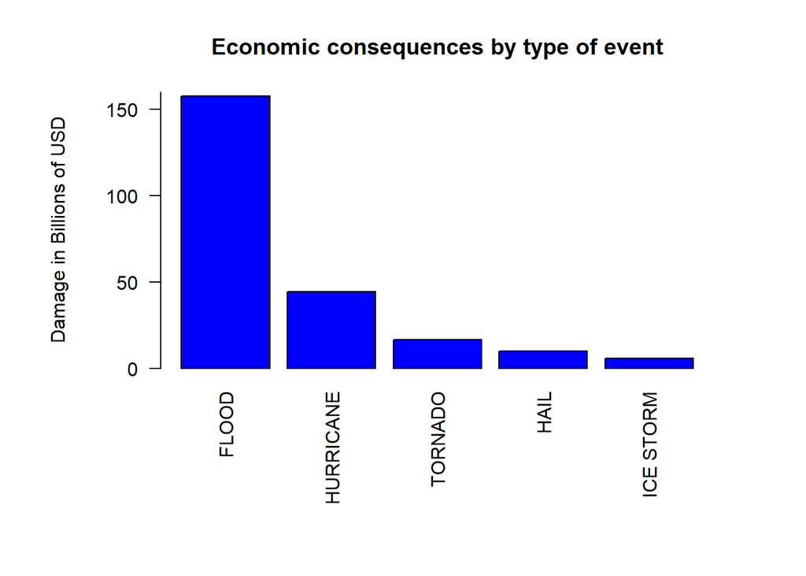

```r
par(mar=c(9, 7, 4, 4))
with(totalimpact, barplot(height = DAMAGE_IN_BUSD,
                               col= "blue",
                               main = "Economic consequences by type of event",
                               yaxt="n",
                               xlab="", ylab="",
                               ylim= c(0,160),
                               names.arg = EVTYPE,
                               las = 2))
mtext(text="Event Type", side = 1, line = 9)
mtext(text="Damage in Billions of USD", side = 2, line = 4)
axis(2, at=pretty(totalimpact$DAMAGE_IN_BUSD),
     labels = format(pretty(totalimpact$DAMAGE_IN_BUSD), scientific=FALSE), las=1)
```

The event with the worst economic consequences is Floods. If we analyzed the information separately (property damage and crop damage), the result is very interesting. In the case of properties the event with the worst economic consequences is flood but in the case of crops is drought.

```r
head(totalpropdamage, 5)
```

```
## # A tibble: 5 x 2
##   EVTYPE      PROPERTYDAMAGE_MUSD
##   <chr>                     <dbl>
## 1 FLOOD                   168212.
## 2 HURRICANE                84756.
## 3 TORNADO                  56999.
## 4 STORM SURGE              47965.
## 5 HAIL                     15735.
```

```r
head(totalcropdamage, 5)
```

```
## # A tibble: 5 x 2
##   EVTYPE    CROPDAMAGE_MUSD
##   <chr>               <dbl>
## 1 DROUGHT            13973.
## 2 FLOOD              12380.
## 3 HURRICANE           5515.
## 4 ICE STORM           5022.
## 5 HAIL                3026.
```